# About the Data Set- Heart disease

The dataset used in this assignment is the heart disease dataset available in heart-c.csv from the Blackboard. This dataset describes 13 risk factors for heart disease. The attribute num represents the (binary) class attribute: class <50 means no disease; class >50_1 indicates increased level of heart disease.

Data Dictionary: age = age in years sex = sex (1 = male; 0 = female) cp = cp: chest pain type  
Value 1: typical angina  
Value 2: atypical angina  
Value 3: non-anginal pain  
Value 4: asymptomatic trestbps = resting blood pressure (in mm Hg on admission to the hospital) chol = serum cholestoral in mg/dl fbs = (fasting blood sugar > 120 mg/dl) (1 = true; 0 = false) restecg = resting electrocardiographic results : Value 0: normal  
Value 1: having ST-T wave abnormality (T wave inversions and/or ST elevation or depression of > 0.05 mV)  
Value 2: showing probable or definite left ventricular hypertrophy by Estes' criteria thalach = maximum heart rate achieved exang = exercise induced angina (1 = yes; 0 = no) oldpeak = ST depression induced by exercise relative to rest slope = the slope of the peak exercise ST segment : Value 1: upsloping  
Value 2: flat  
Value 3: downsloping ca = number of major vessels (0-3) colored by flourosopy thal = 3 = normal; 6 = fixed defect; 7 = reversable defect num = diagnosis of heart disease (angiographic disease status) : Value 0: < 50% no disease  
Value 1: > 50% increased level of heart disease

# Load the Required Packages

```r
install.packages("factoextra")
library(tidyverse)
library(dplyr)
library(cluster)
library(factoextra)
options(repr.plot.width = 10, repr.plot.height = 15)
options(scipen=999)
library(dendextend)
```

# Load the Dataset

*Dataset used in the model testing & training & prediction is- heart_c.csv ***

```r
df <- read_csv("../input/pmim402-assignment-datasets/heart-c.csv")
head(df)
summary(df)
```

A tibble: 6 × 15

| ...1 <dbl> | age <dbl> | sex <chr> | cp <chr> | trestbps <dbl> | chol <dbl> | fbs <lgl> | restecg <chr> | thalach <dbl> | exang <chr> | oldpeak <dbl> | slope <chr> | ca <dbl> | thal <chr> | num <chr> |
| --- | --- | --- | --- | --- | --- | --- | --- | --- | --- | --- | --- | --- | --- | --- |
| 1 | 63 | male | typ_angina | 145 | 233 | TRUE | left_vent_hyper | 150 | no | 2.3 | down | 0 | fixed_defect | <50 |
| 2 | 67 | male | asympt | 160 | 286 | FALSE | left_vent_hyper | 108 | yes | 1.5 | flat | 3 | normal | >50_1 |
| 3 | 67 | male | asympt | 120 | 229 | FALSE | left_vent_hyper | 129 | yes | 2.6 | flat | 2 | reversable_defect | >50_1 |
| 4 | 37 | male | non_anginal | 130 | 250 | FALSE | normal | 187 | no | 3.5 | down | 0 | normal | <50 |
| 5 | 41 | female | atyp_angina | 130 | 204 | FALSE | left_vent_hyper | 172 | no | 1.4 | up | 0 | normal | <50 |
| 6 | 56 | male | atyp_angina | 120 | 236 | FALSE | normal | 178 | no | 0.8 | up | 0 | normal | <50 |

```
      ...1            age            sex                 cp
 Min.   :  1.0   Min.   :29.00   Length:303         Length:303
 1st Qu.: 76.5   1st Qu.:47.50   Class :character   Class :character
 Median :152.0   Median :55.00   Mode  :character   Mode  :character
 Mean   :152.0   Mean   :54.37
 3rd Qu.:227.5   3rd Qu.:61.00
 Max.   :303.0   Max.   :77.00

    trestbps          chol          fbs            restecg
 Min.   : 94.0   Min.   :126.0   Mode :logical   Length:303
 1st Qu.:120.0   1st Qu.:211.0   FALSE:258       Class :character
 Median :130.0   Median :240.0   TRUE :45        Mode  :character
 Mean   :131.6   Mean   :246.3
 3rd Qu.:140.0   3rd Qu.:274.5
 Max.   :200.0   Max.   :564.0

    thalach         exang              oldpeak        slope
 Min.   : 71.0   Length:303         Min.   :0.00   Length:303
 1st Qu.:133.5   Class :character   1st Qu.:0.00   Class :character
 Median :153.0   Mode  :character   Median :0.80   Mode  :character
 Mean   :149.6                      Mean   :1.04
 3rd Qu.:166.0                      3rd Qu.:1.60
 Max.   :202.0                      Max.   :6.20

       ca             thal               num
 Min.   :0.0000   Length:303         Length:303
 1st Qu.:0.0000   Class :character   Class :character
 Median :0.0000   Mode  :character   Mode  :character
 Mean   :0.6745
 3rd Qu.:1.0000
 Max.   :3.0000
 NA's   :5
```

# Pre-processing the data

*As the dataset has been has some noise in the data, pre-processing is done to exclude the columns which are not relevant***

```r
df<-na.omit(df) #Remove the NAs
df
str(df) #structure of the dataframe
```

A tibble: 296 × 15

| ...1 <dbl> | age <dbl> | sex <chr> | cp <chr> | trestbps <dbl> | chol <dbl> | fbs <lgl> | restecg <chr> | thalach <dbl> | exang <chr> | oldpeak <dbl> | slope <chr> | ca <dbl> | thal <chr> | num <chr> |
| --- | --- | --- | --- | --- | --- | --- | --- | --- | --- | --- | --- | --- | --- | --- |
| 1 | 63 | male | typ_angina | 145 | 233 | TRUE | left_vent_hyper | 150 | no | 2.3 | down | 0 | fixed_defect | <50 |
| 2 | 67 | male | asympt | 160 | 286 | FALSE | left_vent_hyper | 108 | yes | 1.5 | flat | 3 | normal | >50_1 |
| 3 | 67 | male | asympt | 120 | 229 | FALSE | left_vent_hyper | 129 | yes | 2.6 | flat | 2 | reversable_defect | >50_1 |
| 4 | 37 | male | non_anginal | 130 | 250 | FALSE | normal | 187 | no | 3.5 | down | 0 | normal | <50 |
| 5 | 41 | female | atyp_angina | 130 | 204 | FALSE | left_vent_hyper | 172 | no | 1.4 | up | 0 | normal | <50 |
| 6 | 56 | male | atyp_angina | 120 | 236 | FALSE | normal | 178 | no | 0.8 | up | 0 | normal | <50 |
| 7 | 62 | female | asympt | 140 | 268 | FALSE | left_vent_hyper | 160 | no | 3.6 | down | 2 | normal | >50_1 |
| 8 | 57 | female | asympt | 120 | 354 | FALSE | normal | 163 | yes | 0.6 | up | 0 | normal | <50 |
| 9 | 63 | male | asympt | 130 | 254 | FALSE | left_vent_hyper | 147 | no | 1.4 | flat | 1 | reversable_defect | >50_1 |
| 10 | 53 | male | asympt | 140 | 203 | TRUE | left_vent_hyper | 155 | yes | 3.1 | down | 0 | reversable_defect | >50_1 |
| 11 | 57 | male | asympt | 140 | 192 | FALSE | normal | 148 | no | 0.4 | flat | 0 | fixed_defect | <50 |
| 12 | 56 | female | atyp_angina | 140 | 294 | FALSE | left_vent_hyper | 153 | no | 1.3 | flat | 0 | normal | <50 |
| 13 | 56 | male | non_anginal | 130 | 256 | TRUE | left_vent_hyper | 142 | yes | 0.6 | flat | 1 | fixed_defect | >50_1 |
| 14 | 44 | male | atyp_angina | 120 | 263 | FALSE | normal | 173 | no | 0.0 | up | 0 | reversable_defect | <50 |
| 15 | 52 | male | non_anginal | 172 | 199 | TRUE | normal | 162 | no | 0.5 | up | 0 | reversable_defect | <50 |
| 16 | 57 | male | non_anginal | 150 | 168 | FALSE | normal | 174 | no | 1.6 | up | 0 | normal | <50 |
| 17 | 48 | male | atyp_angina | 110 | 229 | FALSE | normal | 168 | no | 1.0 | down | 0 | reversable_defect | >50_1 |
| 18 | 54 | male | asympt | 140 | 239 | FALSE | normal | 160 | no | 1.2 | up | 0 | normal | <50 |
| 19 | 48 | female | non_anginal | 130 | 275 | FALSE | normal | 139 | no | 0.2 | up | 0 | normal | <50 |
| 20 | 49 | male | atyp_angina | 130 | 266 | FALSE | normal | 171 | no | 0.6 | up | 0 | normal | <50 |
| 21 | 64 | male | typ_angina | 110 | 211 | FALSE | left_vent_hyper | 144 | yes | 1.8 | flat | 0 | normal | <50 |
| 22 | 58 | female | typ_angina | 150 | 283 | TRUE | left_vent_hyper | 162 | no | 1.0 | up | 0 | normal | <50 |
| 23 | 58 | male | atyp_angina | 120 | 284 | FALSE | left_vent_hyper | 160 | no | 1.8 | flat | 0 | normal | >50_1 |
| 24 | 58 | male | non_anginal | 132 | 224 | FALSE | left_vent_hyper | 173 | no | 3.2 | up | 2 | reversable_defect | >50_1 |
| 25 | 60 | male | asympt | 130 | 206 | FALSE | left_vent_hyper | 132 | yes | 2.4 | flat | 2 | reversable_defect | >50_1 |
| 26 | 50 | female | non_anginal | 120 | 219 | FALSE | normal | 158 | no | 1.6 | flat | 0 | normal | <50 |
| 27 | 58 | female | non_anginal | 120 | 340 | FALSE | normal | 172 | no | 0.0 | up | 0 | normal | <50 |
| 28 | 66 | female | typ_angina | 150 | 226 | FALSE | normal | 114 | no | 2.6 | down | 0 | normal | <50 |
| 29 | 43 | male | asympt | 150 | 247 | FALSE | normal | 171 | no | 1.5 | up | 0 | normal | <50 |
| 30 | 40 | male | asympt | 110 | 167 | FALSE | left_vent_hyper | 114 | yes | 2.0 | flat | 0 | reversable_defect | >50_1 |
| ⋮ | ⋮ | ⋮ | ⋮ | ⋮ | ⋮ | ⋮ | ⋮ | ⋮ | ⋮ | ⋮ | ⋮ | ⋮ | ⋮ | ⋮ |
| 271 | 66 | male | asympt | 160 | 228 | FALSE | left_vent_hyper | 138 | no | 2.3 | up | 0 | fixed_defect | <50 |
| 272 | 46 | male | asympt | 140 | 311 | FALSE | normal | 120 | yes | 1.8 | flat | 2 | reversable_defect | >50_1 |
| 273 | 71 | female | asympt | 112 | 149 | FALSE | normal | 125 | no | 1.6 | flat | 0 | normal | <50 |
| 274 | 59 | male | typ_angina | 134 | 204 | FALSE | normal | 162 | no | 0.8 | up | 2 | normal | >50_1 |
| 275 | 64 | male | typ_angina | 170 | 227 | FALSE | left_vent_hyper | 155 | no | 0.6 | flat | 0 | reversable_defect | <50 |
| 276 | 66 | female | non_anginal | 146 | 278 | FALSE | left_vent_hyper | 152 | no | 0.0 | flat | 1 | normal | <50 |
| 277 | 39 | female | non_anginal | 138 | 220 | FALSE | normal | 152 | no | 0.0 | flat | 0 | normal | <50 |
| 278 | 57 | male | atyp_angina | 154 | 232 | FALSE | left_vent_hyper | 164 | no | 0.0 | up | 1 | normal | >50_1 |
| 279 | 58 | female | asympt | 130 | 197 | FALSE | normal | 131 | no | 0.6 | flat | 0 | normal | <50 |
| 280 | 57 | male | asympt | 110 | 335 | FALSE | normal | 143 | yes | 3.0 | flat | 1 | reversable_defect | >50_1 |
| 281 | 47 | male | non_anginal | 130 | 253 | FALSE | normal | 179 | no | 0.0 | up | 0 | normal | <50 |
| 282 | 55 | female | asympt | 128 | 205 | FALSE | st_t_wave_abnormality | 130 | yes | 2.0 | flat | 1 | reversable_defect | >50_1 |
| 283 | 35 | male | atyp_angina | 122 | 192 | FALSE | normal | 174 | no | 0.0 | up | 0 | normal | <50 |
| 284 | 61 | male | asympt | 148 | 203 | FALSE | normal | 161 | no | 0.0 | up | 1 | reversable_defect | >50_1 |
| 285 | 58 | male | asympt | 114 | 318 | FALSE | st_t_wave_abnormality | 140 | no | 4.4 | down | 3 | fixed_defect | >50_1 |
| 286 | 58 | female | asympt | 170 | 225 | TRUE | left_vent_hyper | 146 | yes | 2.8 | flat | 2 | fixed_defect | >50_1 |
| 288 | 56 | male | atyp_angina | 130 | 221 | FALSE | left_vent_hyper | 163 | no | 0.0 | up | 0 | reversable_defect | <50 |
| 289 | 56 | male | atyp_angina | 120 | 240 | FALSE | normal | 169 | no | 0.0 | down | 0 | normal | <50 |
| 290 | 67 | male | non_anginal | 152 | 212 | FALSE | left_vent_hyper | 150 | no | 0.8 | flat | 0 | reversable_defect | >50_1 |
| 291 | 55 | female | atyp_angina | 132 | 342 | FALSE | normal | 166 | no | 1.2 | up | 0 | normal | <50 |
| 292 | 44 | male | asympt | 120 | 169 | FALSE | normal | 144 | yes | 2.8 | down | 0 | fixed_defect | >50_1 |
| 293 | 63 | male | asympt | 140 | 187 | FALSE | left_vent_hyper | 144 | yes | 4.0 | up | 2 | reversable_defect | >50_1 |
| 294 | 63 | female | asympt | 124 | 197 | FALSE | normal | 136 | yes | 0.0 | flat | 0 | normal | >50_1 |
| 295 | 41 | male | atyp_angina | 120 | 157 | FALSE | normal | 182 | no | 0.0 | up | 0 | normal | <50 |
| 296 | 59 | male | asympt | 164 | 176 | TRUE | left_vent_hyper | 90 | no | 1.0 | flat | 2 | fixed_defect | >50_1 |
| 297 | 57 | female | asympt | 140 | 241 | FALSE | normal | 123 | yes | 0.2 | flat | 0 | reversable_defect | >50_1 |
| 298 | 45 | male | typ_angina | 110 | 264 | FALSE | normal | 132 | no | 1.2 | flat | 0 | reversable_defect | >50_1 |
| 299 | 68 | male | asympt | 144 | 193 | TRUE | normal | 141 | no | 3.4 | flat | 2 | reversable_defect | >50_1 |
| 300 | 57 | male | asympt | 130 | 131 | FALSE | normal | 115 | yes | 1.2 | flat | 1 | reversable_defect | >50_1 |
| 301 | 57 | female | atyp_angina | 130 | 236 | FALSE | left_vent_hyper | 174 | no | 0.0 | flat | 1 | normal | >50_1 |

```
tibble [296 × 15] (S3: tbl_df/tbl/data.frame)
 $ ...1    : num [1:296] 1 2 3 4 5 6 7 8 9 10 ...
 $ age     : num [1:296] 63 67 67 37 41 56 62 57 63 53 ...
 $ sex     : chr [1:296] "male" "male" "male" "male" ...
 $ cp      : chr [1:296] "typ_angina" "asympt" "asympt" "non_anginal" ...
 $ trestbps: num [1:296] 145 160 120 130 130 120 140 120 130 140 ...
 $ chol    : num [1:296] 233 286 229 250 204 236 268 354 254 203 ...
 $ fbs     : logi [1:296] TRUE FALSE FALSE FALSE FALSE FALSE ...
 $ restecg : chr [1:296] "left_vent_hyper" "left_vent_hyper" "left_vent_hyper" "normal" ...
 $ thalach : num [1:296] 150 108 129 187 172 178 160 163 147 155 ...
 $ exang   : chr [1:296] "no" "yes" "yes" "no" ...
 $ oldpeak : num [1:296] 2.3 1.5 2.6 3.5 1.4 0.8 3.6 0.6 1.4 3.1 ...
 $ slope   : chr [1:296] "down" "flat" "flat" "down" ...
 $ ca      : num [1:296] 0 3 2 0 0 0 2 0 1 0 ...
 $ thal    : chr [1:296] "fixed_defect" "normal" "reversable_defect" "normal" ...
 $ num     : chr [1:296] "<50" ">50_1" ">50_1" "<50" ...
 - attr(*, "na.action")= 'omit' Named int [1:7] 88 167 192 266 287 302 303
  ..- attr(*, "names")= chr [1:7] "88" "167" "192" "266" ...
```

# Plotting a Histogram for Each Feature

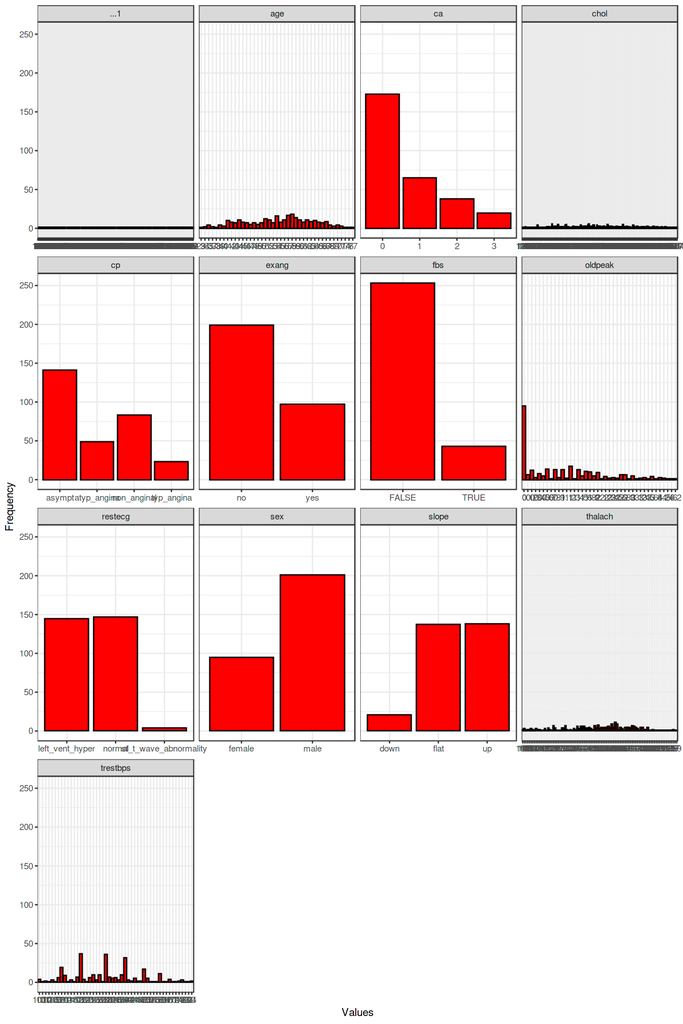

```r
df %>%
  gather(attributes, value, 1:13) %>%    # gather dplyr verb will turn wide data into long format
  ggplot(aes(x = value)) +
  geom_histogram(fill = 'red', color = 'black',stat='count') +
  facet_wrap(~attributes, scales = 'free_x') +
  labs(x="Values", y="Frequency") +
  theme_bw()
```

# Some More Pre-Processing

```r
#Changing the data frame into numeric
#Sex
df<- df %>%
  mutate (sex=if_else(sex=="male",1,2))
#exang
df<- df %>%
  mutate(exang=if_else(exang=="no",1,2))
#fbs
df<- df %>%
  mutate(fbs=if_else(fbs=="TRUE",1,2))

#slope
df <- df %>%
  mutate(slope =if_else(slope=="down",1,if_else(slope=="flat",2,3)))

#cp
df <- df %>%
  mutate(cp =if_else(cp=="typ_angina",1,
            if_else(cp=="asympt",2,
            if_else(cp=="non_anginal",3,4))))
#restecg

df <- df %>%
  mutate(restecg = if_else(restecg =="left_vent_hyper",1,
                   if_else(restecg == "normal",2,3)))
#thal

df<-df %>%
  mutate(thal= if_else(thal=="fixed_defect",1,
               if_else(thal == "normal",2,3)))
```

```r
#Removing the  columns which are not required
df<- select (df,-1,-num)
df
```

A tibble: 296 × 13

| age <dbl> | sex <dbl> | cp <dbl> | trestbps <dbl> | chol <dbl> | fbs <dbl> | restecg <dbl> | thalach <dbl> | exang <dbl> | oldpeak <dbl> | slope <dbl> | ca <dbl> | thal <dbl> |
| --- | --- | --- | --- | --- | --- | --- | --- | --- | --- | --- | --- | --- |
| 63 | 1 | 1 | 145 | 233 | 1 | 1 | 150 | 1 | 2.3 | 1 | 0 | 1 |
| 67 | 1 | 2 | 160 | 286 | 2 | 1 | 108 | 2 | 1.5 | 2 | 3 | 2 |
| 67 | 1 | 2 | 120 | 229 | 2 | 1 | 129 | 2 | 2.6 | 2 | 2 | 3 |
| 37 | 1 | 3 | 130 | 250 | 2 | 2 | 187 | 1 | 3.5 | 1 | 0 | 2 |
| 41 | 2 | 4 | 130 | 204 | 2 | 1 | 172 | 1 | 1.4 | 3 | 0 | 2 |
| 56 | 1 | 4 | 120 | 236 | 2 | 2 | 178 | 1 | 0.8 | 3 | 0 | 2 |
| 62 | 2 | 2 | 140 | 268 | 2 | 1 | 160 | 1 | 3.6 | 1 | 2 | 2 |
| 57 | 2 | 2 | 120 | 354 | 2 | 2 | 163 | 2 | 0.6 | 3 | 0 | 2 |
| 63 | 1 | 2 | 130 | 254 | 2 | 1 | 147 | 1 | 1.4 | 2 | 1 | 3 |
| 53 | 1 | 2 | 140 | 203 | 1 | 1 | 155 | 2 | 3.1 | 1 | 0 | 3 |
| 57 | 1 | 2 | 140 | 192 | 2 | 2 | 148 | 1 | 0.4 | 2 | 0 | 1 |
| 56 | 2 | 4 | 140 | 294 | 2 | 1 | 153 | 1 | 1.3 | 2 | 0 | 2 |
| 56 | 1 | 3 | 130 | 256 | 1 | 1 | 142 | 2 | 0.6 | 2 | 1 | 1 |
| 44 | 1 | 4 | 120 | 263 | 2 | 2 | 173 | 1 | 0.0 | 3 | 0 | 3 |
| 52 | 1 | 3 | 172 | 199 | 1 | 2 | 162 | 1 | 0.5 | 3 | 0 | 3 |
| 57 | 1 | 3 | 150 | 168 | 2 | 2 | 174 | 1 | 1.6 | 3 | 0 | 2 |
| 48 | 1 | 4 | 110 | 229 | 2 | 2 | 168 | 1 | 1.0 | 1 | 0 | 3 |
| 54 | 1 | 2 | 140 | 239 | 2 | 2 | 160 | 1 | 1.2 | 3 | 0 | 2 |
| 48 | 2 | 3 | 130 | 275 | 2 | 2 | 139 | 1 | 0.2 | 3 | 0 | 2 |
| 49 | 1 | 4 | 130 | 266 | 2 | 2 | 171 | 1 | 0.6 | 3 | 0 | 2 |
| 64 | 1 | 1 | 110 | 211 | 2 | 1 | 144 | 2 | 1.8 | 2 | 0 | 2 |
| 58 | 2 | 1 | 150 | 283 | 1 | 1 | 162 | 1 | 1.0 | 3 | 0 | 2 |
| 58 | 1 | 4 | 120 | 284 | 2 | 1 | 160 | 1 | 1.8 | 2 | 0 | 2 |
| 58 | 1 | 3 | 132 | 224 | 2 | 1 | 173 | 1 | 3.2 | 3 | 2 | 3 |
| 60 | 1 | 2 | 130 | 206 | 2 | 1 | 132 | 2 | 2.4 | 2 | 2 | 3 |
| 50 | 2 | 3 | 120 | 219 | 2 | 2 | 158 | 1 | 1.6 | 2 | 0 | 2 |
| 58 | 2 | 3 | 120 | 340 | 2 | 2 | 172 | 1 | 0.0 | 3 | 0 | 2 |
| 66 | 2 | 1 | 150 | 226 | 2 | 2 | 114 | 1 | 2.6 | 1 | 0 | 2 |
| 43 | 1 | 2 | 150 | 247 | 2 | 2 | 171 | 1 | 1.5 | 3 | 0 | 2 |
| 40 | 1 | 2 | 110 | 167 | 2 | 1 | 114 | 2 | 2.0 | 2 | 0 | 3 |
| ⋮ | ⋮ | ⋮ | ⋮ | ⋮ | ⋮ | ⋮ | ⋮ | ⋮ | ⋮ | ⋮ | ⋮ | ⋮ |
| 66 | 1 | 2 | 160 | 228 | 2 | 1 | 138 | 1 | 2.3 | 3 | 0 | 1 |
| 46 | 1 | 2 | 140 | 311 | 2 | 2 | 120 | 2 | 1.8 | 2 | 2 | 3 |
| 71 | 2 | 2 | 112 | 149 | 2 | 2 | 125 | 1 | 1.6 | 2 | 0 | 2 |
| 59 | 1 | 1 | 134 | 204 | 2 | 2 | 162 | 1 | 0.8 | 3 | 2 | 2 |
| 64 | 1 | 1 | 170 | 227 | 2 | 1 | 155 | 1 | 0.6 | 2 | 0 | 3 |
| 66 | 2 | 3 | 146 | 278 | 2 | 1 | 152 | 1 | 0.0 | 2 | 1 | 2 |
| 39 | 2 | 3 | 138 | 220 | 2 | 2 | 152 | 1 | 0.0 | 2 | 0 | 2 |
| 57 | 1 | 4 | 154 | 232 | 2 | 1 | 164 | 1 | 0.0 | 3 | 1 | 2 |
| 58 | 2 | 2 | 130 | 197 | 2 | 2 | 131 | 1 | 0.6 | 2 | 0 | 2 |
| 57 | 1 | 2 | 110 | 335 | 2 | 2 | 143 | 2 | 3.0 | 2 | 1 | 3 |
| 47 | 1 | 3 | 130 | 253 | 2 | 2 | 179 | 1 | 0.0 | 3 | 0 | 2 |
| 55 | 2 | 2 | 128 | 205 | 2 | 3 | 130 | 2 | 2.0 | 2 | 1 | 3 |
| 35 | 1 | 4 | 122 | 192 | 2 | 2 | 174 | 1 | 0.0 | 3 | 0 | 2 |
| 61 | 1 | 2 | 148 | 203 | 2 | 2 | 161 | 1 | 0.0 | 3 | 1 | 3 |
| 58 | 1 | 2 | 114 | 318 | 2 | 3 | 140 | 1 | 4.4 | 1 | 3 | 1 |
| 58 | 2 | 2 | 170 | 225 | 1 | 1 | 146 | 2 | 2.8 | 2 | 2 | 1 |
| 56 | 1 | 4 | 130 | 221 | 2 | 1 | 163 | 1 | 0.0 | 3 | 0 | 3 |
| 56 | 1 | 4 | 120 | 240 | 2 | 2 | 169 | 1 | 0.0 | 1 | 0 | 2 |
| 67 | 1 | 3 | 152 | 212 | 2 | 1 | 150 | 1 | 0.8 | 2 | 0 | 3 |
| 55 | 2 | 4 | 132 | 342 | 2 | 2 | 166 | 1 | 1.2 | 3 | 0 | 2 |
| 44 | 1 | 2 | 120 | 169 | 2 | 2 | 144 | 2 | 2.8 | 1 | 0 | 1 |
| 63 | 1 | 2 | 140 | 187 | 2 | 1 | 144 | 2 | 4.0 | 3 | 2 | 3 |
| 63 | 2 | 2 | 124 | 197 | 2 | 2 | 136 | 2 | 0.0 | 2 | 0 | 2 |
| 41 | 1 | 4 | 120 | 157 | 2 | 2 | 182 | 1 | 0.0 | 3 | 0 | 2 |
| 59 | 1 | 2 | 164 | 176 | 1 | 1 | 90 | 1 | 1.0 | 2 | 2 | 1 |
| 57 | 2 | 2 | 140 | 241 | 2 | 2 | 123 | 2 | 0.2 | 2 | 0 | 3 |
| 45 | 1 | 1 | 110 | 264 | 2 | 2 | 132 | 1 | 1.2 | 2 | 0 | 3 |
| 68 | 1 | 2 | 144 | 193 | 1 | 2 | 141 | 1 | 3.4 | 2 | 2 | 3 |
| 57 | 1 | 2 | 130 | 131 | 2 | 2 | 115 | 2 | 1.2 | 2 | 1 | 3 |
| 57 | 2 | 4 | 130 | 236 | 2 | 1 | 174 | 1 | 0.0 | 2 | 1 | 2 |

# Processed Dataframe

```r
#as data frame scale fucntion to normalise the data
dfNorm <- as.data.frame(scale(df))
head(dfNorm)
```

A data.frame: 6 × 13

|  | age <dbl> | sex <dbl> | cp <dbl> | trestbps <dbl> | chol <dbl> | fbs <dbl> | restecg <dbl> | thalach <dbl> | exang <dbl> | oldpeak <dbl> | slope <dbl> | ca <dbl> | thal <dbl> |
| --- | --- | --- | --- | --- | --- | --- | --- | --- | --- | --- | --- | --- | --- |
| 1 | 0.9356342 | -0.6863236 | -1.7855980 | 0.75565845 | -0.27233974 | -2.4215374 | -0.9942209 | 0.01911946 | -0.6969867 | 1.0637854 | -2.2568597 | -0.7226085 | -2.2667000 |
| 2 | 1.3771611 | -0.6863236 | -0.6214196 | 1.60184344 | 0.74734183 | 0.4115656 | -0.9942209 | -1.80928938 | 1.4299005 | 0.3779581 | -0.6393525 | 2.4698110 | -0.5594654 |
| 3 | 1.3771611 | -0.6863236 | -0.6214196 | -0.65464988 | -0.34929683 | 0.4115656 | -0.9942209 | -0.89508496 | 1.4299005 | 1.3209707 | -0.6393525 | 1.4056712 | 1.1477692 |
| 4 | -1.9342905 | -0.6863236 | 0.5427589 | -0.09052655 | 0.05472794 | 0.4115656 | 0.9044203 | 1.62986058 | -0.6969867 | 2.0925265 | -2.2568597 | -0.7226085 | -0.5594654 |
| 5 | -1.4927636 | 1.4521162 | 1.7069373 | -0.09052655 | -0.83027871 | 0.4115656 | -0.9942209 | 0.97685743 | -0.6969867 | 0.2922297 | 0.9781547 | -0.7226085 | -0.5594654 |
| 6 | 0.1629622 | -0.6863236 | 1.7069373 | -0.65464988 | -0.21462191 | 0.4115656 | 0.9044203 | 1.23805869 | -0.6969867 | -0.2221409 | 0.9781547 | -0.7226085 | -0.5594654 |

# Section-1-Elbow Method for Optimal Value of k

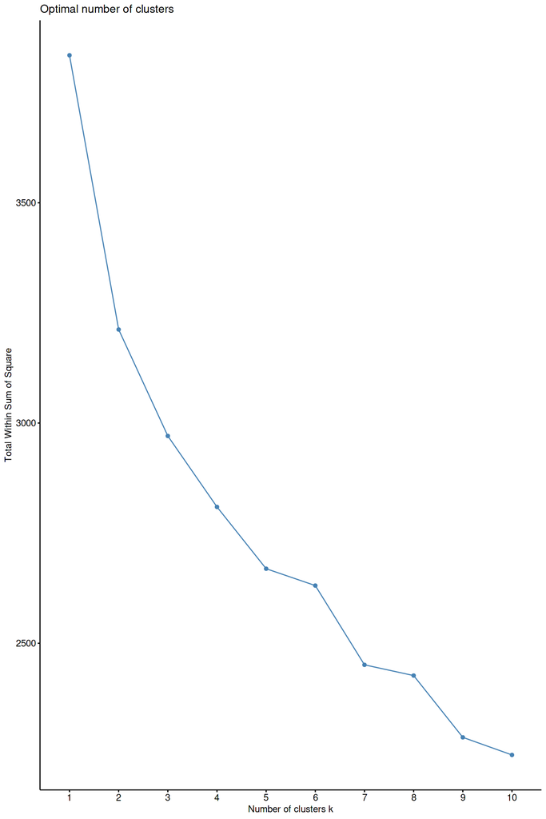

```r
#K Means
#Elbow methods for optimal no of cluster
fviz_nbclust(dfNorm,kmeans,method='wss')
```

```
K-means clustering with 2 clusters of sizes 135, 161

Cluster means:
         age        sex        cp   trestbps        chol         fbs    restecg
1  0.4679428 -0.1794342 -0.517937  0.2212038  0.09548670 -0.09209712 -0.1925724
2 -0.3923744  0.1504572  0.434295 -0.1854815 -0.08006649  0.07722429  0.1614737
     thalach      exang    oldpeak      slope         ca       thal
1 -0.6770948  0.5633909  0.6681647 -0.6513340  0.4124740  0.2625365
2  0.5677503 -0.4724085 -0.5602623  0.5461497 -0.3458633 -0.2201393

Clustering vector:
  [1] 1 1 1 2 2 2 1 2 1 1 2 2 1 2 2 2 2 2 2 2 1 2 2 1 1 2 2 1 2 1 1 1 2 2 2 2 1
 [38] 1 1 1 1 2 2 2 2 1 2 1 2 1 2 2 2 2 1 1 2 2 1 1 1 1 1 2 1 1 1 2 1 1 2 1 1 2
 [75] 2 2 1 2 2 1 1 2 2 1 2 2 2 2 2 1 1 1 2 2 2 1 1 2 2 2 2 2 2 1 2 2 2 1 2 1 1
[112] 2 1 1 2 2 2 1 1 1 1 2 1 1 2 1 1 2 2 2 2 2 2 2 2 1 1 1 2 2 1 2 1 1 2 1 2 2
[149] 2 1 2 1 1 1 1 2 2 1 2 2 1 2 1 2 2 2 2 2 1 1 1 1 1 1 2 1 2 2 2 1 2 1 2 2 1
[186] 2 1 2 1 1 1 1 1 2 2 1 2 2 2 2 2 1 1 1 2 1 2 1 2 1 2 1 2 2 1 2 2 2 2 1 1 2
[223] 2 2 1 1 2 1 2 1 2 1 1 2 2 2 2 2 2 1 2 1 2 1 2 2 1 1 1 2 2 2 2 1 2 2 2 2 2
[260] 2 1 1 1 2 2 1 1 1 1 2 1 2 2 2 2 1 2 1 2 2 1 1 2 2 1 2 1 1 1 2 1 1 1 1 1 2

Within cluster sum of squares by cluster:
[1] 1724.932 1487.425
 (between_SS / total_SS =  16.2 %)

Available components:

[1] "cluster"      "centers"      "totss"        "withinss"     "tot.withinss"
[6] "betweenss"    "size"         "iter"         "ifault"
```

3212.35678016341

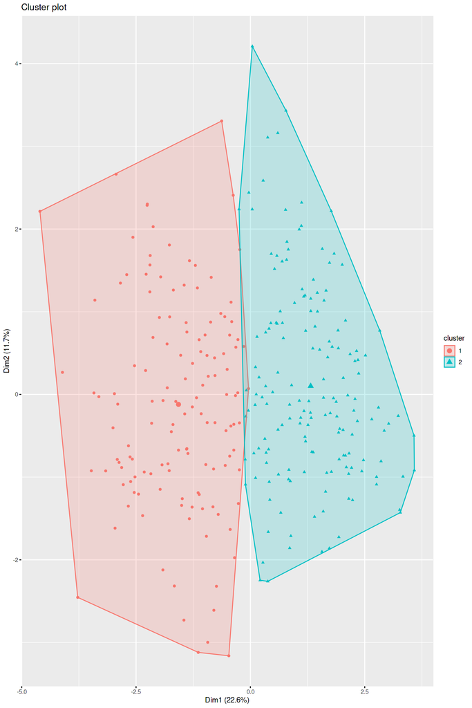

```r
#clustering
df_K2 <- kmeans(dfNorm, centers = 2)
df_K2
fviz_cluster(df_K2, geom = "point", data =dfNorm)
df_K2$tot.withinss
```

# Error Rate

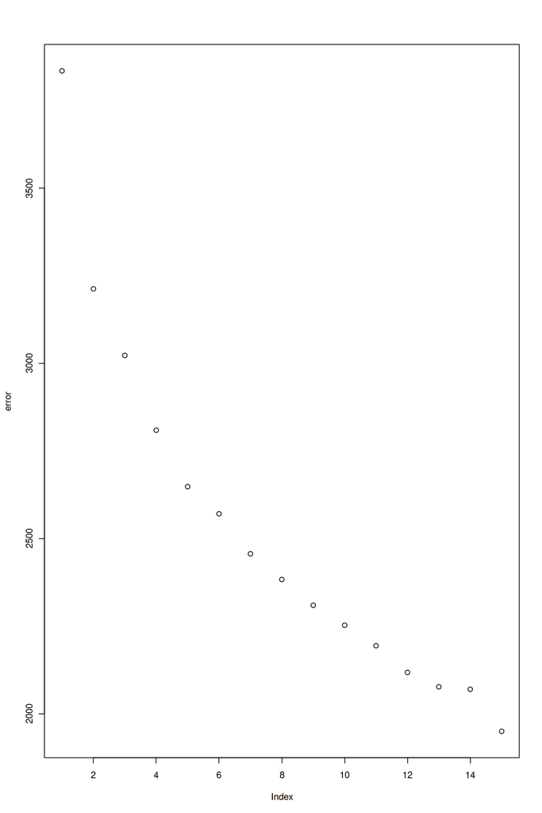

```r
#error rate
error<- vector()
 for (i in 1:15) {
   error[i]<- kmeans(dfNorm,i)$tot.withinss

 }
plot(error)
```

# Section-2- Hierarchical Dendogram for Tree Diagram

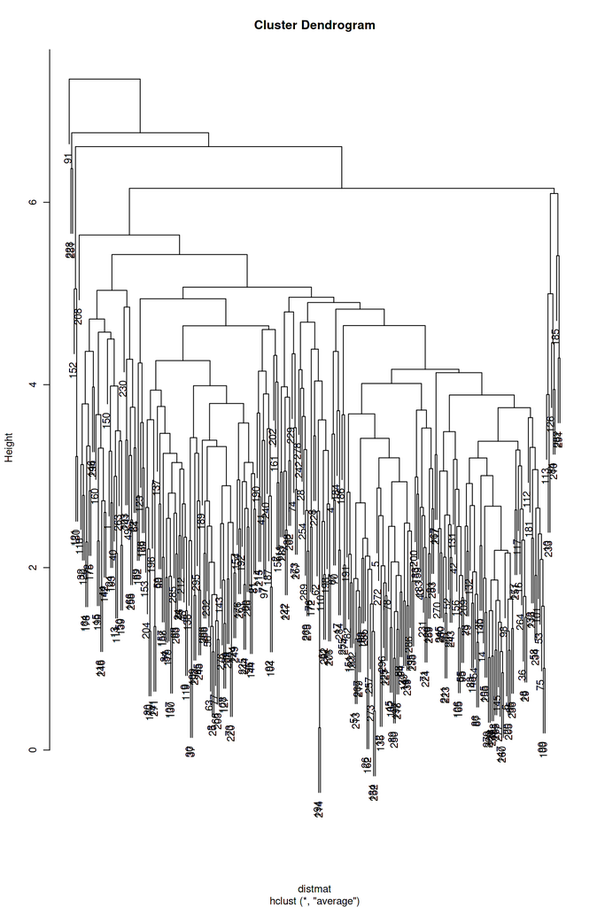

```r
distmat<- dist(dfNorm, method= 'euclidean')
hclust_avg<- hclust(distmat, method = 'average')
plot(hclust_avg)
```

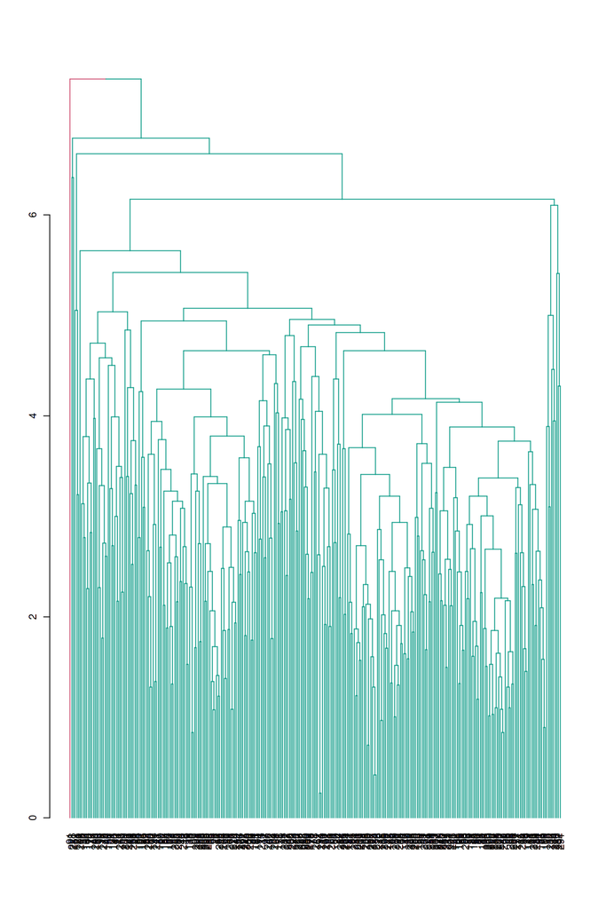

```r
#Dendogram- Addding colour, using library(dendextend)
avg_dend_obj <- as.dendrogram(hclust_avg)
avg_col_dend <- color_branches(avg_dend_obj, k = 2)
plot(avg_col_dend)
```